# Assignment 04 - Solutions

Statistical Computing and Empirical Methods

ROHAN ANTHONY (2704500)

## A word of advice

Think of the SCEM labs as going to the gym: if you pay a gym membership, but instead of working out you use a machine to lift the weights for you, you won’t get the benefits.

ChatGPT, DeepSeek, Claude and other GenAI tools can provide answers to most of the questions below. Before you try that, please consider the following: answering the specific questions below is not the point of this assignment. Instead, the questions are designed to give you the chance to develop a better understanding of estimation concepts and a certain level of **statistical thinking**. These are essential skills for any data scientist, even if they end up using generative AI - to write an effective prompt and to catch the common (often subtle) errors that AI produces when trying to solve anything non-trivial.

A very important part of this learning involves not having the answers ready-made for you, but instead taking the time to actually search for the answer, trying something, getting it wrong, and trying again.

So, make the best use of this session. The assignments are not marked, so it is much better to try the yourself even if you get incorrect answers (you’ll be able to correct yourself later when you receive feedback) than to submit a perfect, but GPT’d solution.

## IMPORTANT NOTES:

- **DO NOT** change the code block names. Enter your solutions to each question into the predefined code blocks.
- **DO NOT** add calls to `install.packages()` into your solutions. Some questions may require you to load packages using `library()`. Please do not use any other packages except the ones explicitly listed in the “setup” code block.

## Part I: Tidy data and iteration

### Q1: Missing data and iteration

**a.** Define the function called `impute_by_median` and test it using the test vector `xtest`.

```r
## Question 1.a
xtest <- c(1, 2, 3, 4, NA, 6, NA, 8, 9, 10)

# impute_by_median <- function...
impute_by_median <- function(x) {
  x_median <- median(x, na.rm = TRUE)
  impute <- function(z) {
    if (is.na(z)) {
      return(x_median)
    } else {
      return(z)
    }
  }
  return(map_dbl(x, impute))
}

x <- impute_by_median(xtest)
xtest
```

```
##  [1]  1  2  3  4 NA  6 NA  8  9 10
```

```r
x
```

```
##  [1]  1  2  3  4  5  6  5  8  9 10
```

**b.** Build your data frame following the instructions in the assignment specs and store it as a data frame called `df_xy`.

```r
## Question 1.b

# df_xy <- ...
x <- seq(0, 10, 0.1)
y <- 5*x+1
df_xy <- data.frame(x=x, y=y)
head(df_xy)
```

```
##     x   y
## 1 0.0 1.0
## 2 0.1 1.5
## 3 0.2 2.0
## 4 0.3 2.5
## 5 0.4 3.0
## 6 0.5 3.5
```

**c.** Define function `sometimes_missing()` and produce the dataset `df_xy_missing` following the instructions from the assignment specs.

```r
## TWO EXAMPLES OF USING map2
library(dplyr)
library(purrr)

# Trivial example:
df_xy %>%
  mutate(z = map2_dbl(x, y, .f = ~.x + .y)) %>%
  head(n=5)
```

```
##     x   y   z
## 1 0.0 1.0 1.0
## 2 0.1 1.5 1.6
## 3 0.2 2.0 2.2
## 4 0.3 2.5 2.8
## 5 0.4 3.0 3.4
```

```r
# A bit more complex:
# Student grades (%) per assessment of three different units
grades <- list(
  c(90, 85, 88),
  c(70, 80, 75, 85),
  c(100, 95)
)

# Assessment weights per unit
weights <- list(
  c(0.3, 0.3, 0.4),
  c(0.25, 0.25, 0.25, 0.25),
  c(0.6, 0.4)
)

# Weighted mean for each unit
map2_dbl(grades, weights, ~ sum(.x * .y))
```

```
## [1] 87.7 77.5 98.0
```

```r
## Question 1.c

## sometimes_missing <- function...
sometimes_missing <- function(index, value) {
  if (index%%5==0) {
    return(NA)
  } else {
    return(value)
  }
}
sometimes_missing(12, 3)
```

```
## [1] 3
```

```r
sometimes_missing(15, 3)
```

```
## [1] NA
```

```r
## df_xy_missing <- ...
df_xy_missing <- df_xy %>%
  mutate(index = row_number(), y_val = 5*x+1,
         y=map2_dbl(index, y_val, sometimes_missing)) %>%
  select(x,y)
df_xy_missing %>% head(10)
```

```
##      x   y
## 1  0.0 1.0
## 2  0.1 1.5
## 3  0.2 2.0
## 4  0.3 2.5
## 5  0.4  NA
## 6  0.5 3.5
## 7  0.6 4.0
## 8  0.7 4.5
## 9  0.8 5.0
## 10 0.9  NA
```

**d.** Build your data frame following the instructions in the assignment specs and store it as a data frame called `df_xy_imputed`.

```r
## Question 1.d

# df_xy_imputed <- ...
df_xy_imputed <- df_xy_missing %>%
  mutate(y=impute_by_median(y))
df_xy_imputed %>% head(10)
```

```
##      x    y
## 1  0.0  1.0
## 2  0.1  1.5
## 3  0.2  2.0
## 4  0.3  2.5
## 5  0.4 26.0
## 6  0.5  3.5
## 7  0.6  4.0
## 8  0.7  4.5
## 9  0.8  5.0
## 10 0.9 26.0
```

### Q2:

**a.** Follow the instructions from the assignment template to load the data from `HockeyLeague.xlsx` and produce a tidy data frame called `wins_tidy`.

```r
## Question 2.a
folder_path <- "C:/Users/rohta/OneDrive/Desktop/MSc Data Science/SCEM - Statistical Computing and Empirical Methods/Labs/Hello-R/Week 4"
file_path <- paste0(folder_path, "/HockeyLeague.xlsx")
wins_data_frame <- read_excel(file_path, sheet = "Wins")
## New names:
## • `` -> `...1`

# wins_tidy <- ...
wins_tidy <- wins_data_frame %>%
  rename(Team = ...1) %>%
  pivot_longer(
    cols = -Team,
    names_to = "Year",
    values_to = "Result"
  ) %>%
  separate(
    col = Result,
    into = c("Wins", "Total"),
    sep = " of "
  ) %>%
  mutate(
    Year = as.integer(Year),
    Wins = as.integer(Wins),
    Total = as.integer(Total)
  )
wins_tidy %>% head(5)
```

```
## # A tibble: 5 × 4
##   Team   Year  Wins Total
##   <chr> <int> <int> <int>
## 1 Ducks  1990    30    50
## 2 Ducks  1991    11    50
## 3 Ducks  1992    30    50
## 4 Ducks  1993    12    50
## 5 Ducks  1994    24    50
```

```r
# Check the dimension of your resulting dataframe:
dim(wins_tidy)
```

```
## [1] 248   4
```

```r
# Check the column classes:
sapply(wins_tidy, class) ## equivalent to map_chr(wins_tidy, class)
```

```
##        Team        Year        Wins       Total
## "character"   "integer"   "integer"   "integer"
```

```r
# Check the top 4 rows:
wins_tidy %>% print(n = 4)
```

```
## # A tibble: 248 × 4
##   Team   Year  Wins Total
##   <chr> <int> <int> <int>
## 1 Ducks  1990    30    50
## 2 Ducks  1991    11    50
## 3 Ducks  1992    30    50
## 4 Ducks  1993    12    50
## # ℹ 244 more rows
```

**b.** Follow the instructions from the assignment template to produce a tidy data frame called `losses_tidy`.

```r
## Question 2.b
losses_data_frame <- read_excel(file_path, sheet = "Losses")
## New names:
## • `` -> `...1`


# losses_tidy <- ...
losses_tidy <- losses_data_frame %>%
  rename(Team = ...1) %>%
  pivot_longer(
    cols = -Team,
    names_to = "Year",
    values_to = "Result"
  ) %>%
  separate(
    col = Result,
    into = c("Losses", "Total"),
    sep = " of "
  ) %>%
  mutate(
    Year = as.integer(Year),
    Losses = as.integer(Losses),
    Total = as.integer(Total)
  )
losses_tidy %>% head(10)
```

```
## # A tibble: 10 × 4
##    Team   Year Losses Total
##    <chr> <int>  <int> <int>
##  1 Ducks  1990     20    50
##  2 Ducks  1991     37    50
##  3 Ducks  1992      1    50
##  4 Ducks  1993     30    50
##  5 Ducks  1994      7    50
##  6 Ducks  1995      2    50
##  7 Ducks  1996     20    50
##  8 Ducks  1997      9    50
##  9 Ducks  1998     17    50
## 10 Ducks  1999     23    50
```

**c.** Follow the instructions from the assignment template to produce a the data frame called `hockey_df`.

```r
## Question 2.c



# hockey_df <- ...
hockey_df <- wins_tidy %>%
  inner_join(losses_tidy, by = c("Team", "Year"), suffix = c("_wins", "_losses")) %>%
  rename(Total = Total_wins) %>%
  mutate(
    Draws = Total - (Wins + Losses),
    Wins_rt = Wins/Total,
    Losses_rt = Losses/Total,
    Draws_rt = Draws/Total
  ) %>%
  select(Team, Year, Wins, Losses, Draws, Total, Wins_rt, Losses_rt, Draws_rt)
dim(hockey_df)
```

```
## [1] 248   9
```

```r
hockey_df %>% head(5)
```

```
## # A tibble: 5 × 9
##   Team   Year  Wins Losses Draws Total Wins_rt Losses_rt Draws_rt
##   <chr> <int> <int>  <int> <int> <int>   <dbl>     <dbl>    <dbl>
## 1 Ducks  1990    30     20     0    50    0.6       0.4      0
## 2 Ducks  1991    11     37     2    50    0.22      0.74     0.04
## 3 Ducks  1992    30      1    19    50    0.6       0.02     0.38
## 4 Ducks  1993    12     30     8    50    0.24      0.6      0.16
## 5 Ducks  1994    24      7    19    50    0.48      0.14     0.38
```

**d.** Follow the instructions from the assignment template to produce a the data frame called `summary_teams`.

```r
## Question 2.d


# summary_teams <- ...
summary_teams <- hockey_df %>%
  group_by(Team) %>%
  summarise(
    median_win_rate = median(Wins_rt, na.rm = TRUE),
    mean_win_rate = mean(Wins_rt, na.rm  =TRUE),
    median_loss_rate = median(Losses_rt, na.rm = TRUE),
    mean_loss_rate = mean(Losses_rt, na.rm = TRUE),
  )%>%
  arrange(desc(median_win_rate))

nrow(summary_teams)
```

```
## [1] 8
```

```r
summary_teams
```

```
## # A tibble: 8 × 5
##   Team        median_win_rate mean_win_rate median_loss_rate mean_loss_rate
##   <chr>                 <dbl>         <dbl>            <dbl>          <dbl>
## 1 Eagles                0.45          0.437            0.25           0.279
## 2 Penguins              0.45          0.457            0.3            0.310
## 3 Hawks                 0.417         0.388            0.233          0.246
## 4 Ducks                 0.383         0.362            0.34           0.333
## 5 Owls                  0.32          0.333            0.3            0.33
## 6 Ostriches             0.3           0.309            0.4            0.395
## 7 Storks                0.3           0.284            0.22           0.283
## 8 Kingfishers           0.233         0.245            0.34           0.360
```

## Part II: Confidence intervals

### Q3: CIs for the Mean and Variance of a normal variable

```r
## Question 3.a
set.seed(MY_STUDENT_ID)                               ## <-- don't change this
known_var <- runif(1, min = 1, max = 3)               ## <-- don't change this
xtest2 <- rnorm(10, mean = 5, sd = sqrt(known_var))   ## <-- don't change this

## Your code starts below this line

# ci_mean_known_var <- function...
ci_mean_known_var <- function(x, var, conf.level) {
  n <- length(x)
  alpha <- 1-conf.level
  z <- qnorm(1-alpha/2)
  xbar <- mean(x)
  se <- sqrt(var/n)
  lower <- xbar-z*se
  upper <- xbar+z*se
  return(c(lower=lower,upper=upper))
}
```

```r
## Question 3.b


# ci_variance <- function...
ci_variance <- function(x, conf.level) {
  n <- length(x)
  s2 <- var(x)
  alpha <- 1 - conf.level
  lower_chi <- qchisq(1-alpha/2, df = n-1)
  upper_chi <- qchisq(alpha/2, df=n-1)
  lower <- (n-1)*s2/lower_chi
  upper <- (n-1)*s2/upper_chi
  return(c(lower=lower,upper=upper))
}
```

```r
## Question 3.c


# ci_mean_t <- function...
ci_mean_t <- function(x, conf.level) {
  n<- length(x)
  alpha <- 1-conf.level
  tq <- qt(1-alpha/2, df=n-1)
  xbar <- mean(x)
  se <- sd(x)/sqrt(n)
  lower <-xbar-tq*se
  upper <-xbar+tq*se
  return(c(lower=lower,upper=upper))
}

# an interval half-length can be calculated from a vector 'x' containing a CI using
# diff(x) / 2.
```

**d.** Build the required data frame and plot the observed differences in the half-widths of CIs obtained using your functions, as explained in the assignment specs.

```r
## Question 3.d
set.seed(MY_STUDENT_ID) ## <-- don't change this

Ns <- 2:30
results <- map_df(Ns,function(N) {
  x <- rnorm(N, mean=0, sd=1)
  ci_z <- ci_mean_known_var(x, 1, 0.95)
  ci_t <- ci_mean_t(x, 0.95)
  tibble(N=N,
         CI.hw.norm = (ci_z["upper"]-ci_z["lower"])/2,
         CI.hw.t = (ci_t["upper"]-ci_t["lower"])/2
         )
})
print(results)
```

```
## # A tibble: 29 × 3
##        N CI.hw.norm CI.hw.t
##    <int>      <dbl>   <dbl>
##  1     2      1.39    1.32
##  2     3      1.13    2.10
##  3     4      0.980   1.78
##  4     5      0.877   1.14
##  5     6      0.800   1.40
##  6     7      0.741   0.882
##  7     8      0.693   0.762
##  8     9      0.653   0.610
##  9    10      0.620   0.625
## 10    11      0.591   0.375
## # ℹ 19 more rows
```

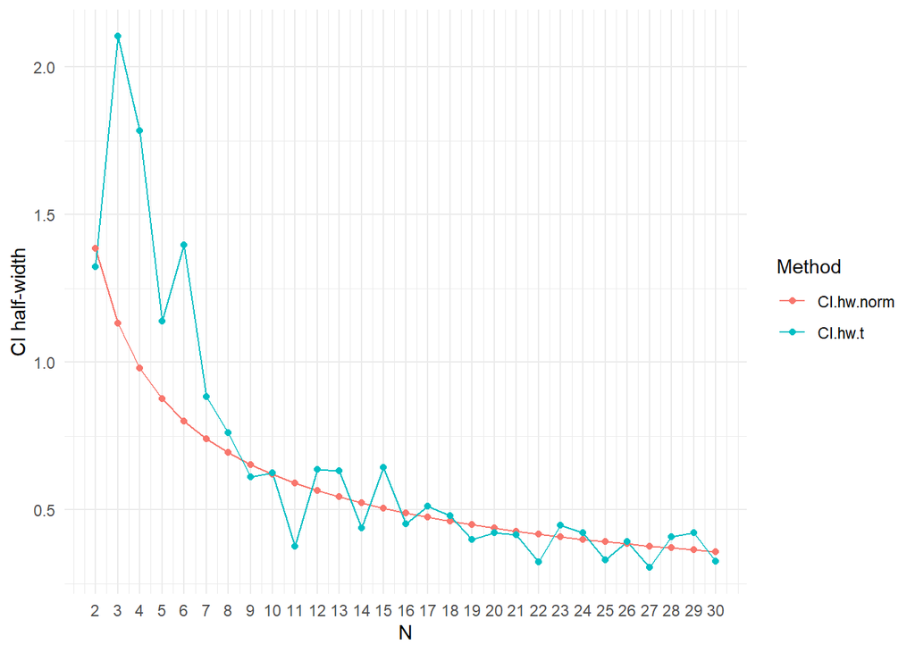

```r
plot_df <- results %>%
  pivot_longer(cols = c(CI.hw.norm, CI.hw.t), names_to="method", values_to="halfwidth")

ggplot(plot_df, aes(x = N, y=halfwidth, color=method)) +
  geom_line()+
  geom_point(size=1.5) +
  scale_x_continuous(breaks = Ns)+
  labs(x="N", y="CI half-width", color = "Method")+
  theme_minimal()
```

## Q4: bootstrap confidence intervals

**a.** Build the function `median_boot_ci` as indicated in the CW specs

```r
## Question 4.a
median_boot_ci <- function(x, R, conf) {
  boot_meds <- replicate(R, median(sample(x, size=length(x), replace=TRUE)))
  alpha <- 1-conf
  probs <- c(alpha/2, 1-alpha/2)
  q<- quantile(boot_meds, probs=probs, na.rm=TRUE)
  return(c(lower = unname(q[1]), upper=unname(q[2])))
}
```

**b.** Calculate the confidence interval as indicated in the assignment specs.

```r
## Question 4.b
file_path <-paste0(folder_path, "/pharma_drug_spending.csv")
oecd.pharma<- read_csv(file_path)
usd_2022 <- oecd.pharma %>%
  filter(TIME==2002)%>%
  pull(USD_CAP)
# med_usd_cap_ci <- ...
med_usd_cap_ci <- median_boot_ci(usd_2022, 2000, 0.95)
med_usd_cap_ci
```

```
##   lower   upper
## 340.848 408.498
```

**c.** Calculate the mean and $95\%$ CI on the median %GDP spent per year on pharmaceutical drugs in OECD countries, and generate the plot as indicated in the assignment specs.

```r
## Question 4.c
years_range <- 1980:2020
median_by_year <- oecd.pharma %>%
  filter(TIME >= min(years_range) & TIME<= max(years_range)) %>%
  group_by(TIME) %>%
  summarise(
    median_pc_gdp = median(PC_GDP, na.rm = TRUE),
    ci = list(median_boot_ci(PC_GDP, 2000, 0.95)),
    .groups = "drop"
  ) %>%
  unnest_wider(ci, names_sep = ".") %>%
  rename(Year = TIME, CI_lower = ci.lower, CI_upper = ci.upper)
head(median_by_year)
```

```
## # A tibble: 6 × 4
##    Year median_pc_gdp CI_lower CI_upper
##   <dbl>         <dbl>    <dbl>    <dbl>
## 1  1980         0.724    0.596    1.00
## 2  1981         0.682    0.572    0.856
## 3  1982         0.704    0.614    0.853
## 4  1983         0.704    0.602    0.852
## 5  1984         0.713    0.606    0.99
## 6  1985         0.738    0.639    1.07
```

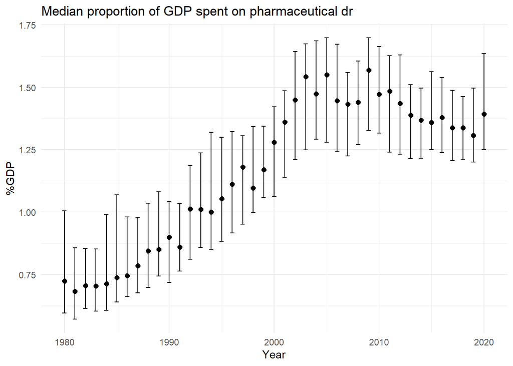

```r
ggplot(median_by_year, aes(x = Year, y = median_pc_gdp))+
  geom_point(size=2)+
  geom_errorbar(aes(ymin = CI_lower, ymax = CI_upper), width = 0.4)+
  labs(
    title = "Median proportion of GDP spent on pharmaceutical dr",
    x = "Year",
    y = "%GDP"
  )+
  theme_minimal()
```